# Assignment2 : Deep Learning

Abha Sharma

2024-03-25

## Introduction :

**GitHub Topic : Deep Learning**

**Summary :**

Deep learning is an AI function and subset of machine learning, used for processing large amounts of complex data. Unlike traditional machine learning techniques, which often require manual feature engineering, deep learning algorithms are capable of automatically learning representations from raw data, enabling them to tackle complex tasks with minimal human intervention.

There are approximately 66,725 public repositories matching this topic.

Repositories can be accessed at [url](https://github.com/topics/deep-learning) .

## Importing the library :

```r
if (!require('tidyverse')) install.packages('tidyverse'); library('tidyverse')
if (!require('gh')) install.packages('gh'); library('gh')
if (!require('kableExtra')) install.packages('kableExtra'); library('kableExtra')
if (!require('ggplot2')) install.packages('ggplot2'); library('ggplot2')
if (!require('ggthemes')) install.packages('ggthemes'); library('ggthemes')
```

## Connecting to GitHub via access token :

```r
my_token = "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"
Sys.setenv(GITHUB_TOKEN = my_token)
```

## Retrieve 100 repositories from GitHub pertaining to the chosen topic :

```r
#search_results
query <- "topic:deep-learning"

# Search for repositories matching the query
search_results <- gh("/search/repositories", q = query, .limit = 100)

# Extract repository information
repository_info <- search_results$items

# Print the repository information
length(repository_info)
```

```
## [1] 100
```

## Creating tables for the repositories obtained in previous steps :

#### Table 1 : Summarizing the repository data.

```r
repos_info <- repository_info %>%
  map_df(~ tibble(
    full_name = .x$full_name,
    created_at = ifelse(is.null(.x$created_at), NA, .x$created_at),
    size = ifelse(is.null(.x$size), NA, .x$size),
    language = ifelse(is.null(.x$language), "Not Specified", .x$language),
    topics = ifelse(length(.x$topics) == 0, "No topics", paste(.x$topics, collapse = ", "))
  ))

sorted_repos_info <- repos_info[order(repos_info$size, decreasing = TRUE), ]
kable(head(sorted_repos_info, n = 10), format = "html",
      caption = "Top 10 Repositories sorted by size") |> kable_styling(full_width = TRUE, bootstrap_options = c("striped", "hover", "condensed", "responsive"), position = "center")
```

Top 10 Repositories sorted by size

| full_name | created_at | size | language | topics |
| --- | --- | --- | --- | --- |
| Unity-Technologies/ml-agents | 2017-09-08T21:09:04Z | 3016006 | C# | deep-learning, deep-reinforcement-learning, machine-learning, neural-networks, reinforcement-learning, unity, unity3d |
| spmallick/learnopencv | 2015-02-17T08:00:51Z | 2728438 | Jupyter Notebook | ai, computer-vision, computervision, deep-learning, deep-neural-networks, deeplearning, machine-learning, opencv, opencv-cpp, opencv-library, opencv-python, opencv-tutorial, opencv3 |
| HumanSignal/label-studio | 2019-06-19T02:00:44Z | 1971534 | JavaScript | annotation, annotation-tool, annotations, boundingbox, computer-vision, data-labeling, dataset, datasets, deep-learning, image-annotation, image-classification, image-labeling, image-labelling-tool, l… |
| jina-ai/jina | 2020-02-13T17:04:44Z | 1375953 | Python | cloud-native, cncf, deep-learning, docker, fastapi, framework, generative-ai, grpc, jaeger, kubernetes, llmops, machine-learning, microservice, mlops, multimodal, neural-search, opentelemetry, orchest… |
| pytorch/pytorch | 2016-08-13T05:26:41Z | 1035712 | Python | autograd, deep-learning, gpu, machine-learning, neural-network, numpy, python, tensor |
| tensorflow/tensorflow | 2015-11-07T01:19:20Z | 997119 | C++ | deep-learning, deep-neural-networks, distributed, machine-learning, ml, neural-network, python, tensorflow |
| microsoft/CNTK | 2015-11-26T09:52:06Z | 935217 | C++ | c-plus-plus, c-sharp, cntk, cognitive-toolkit, deep-learning, deep-neural-networks, distributed, java, machine-learning, neural-network, python |
| iperov/DeepFaceLab | 2018-06-04T13:10:00Z | 848593 | Python | arxiv, creating-deepfakes, deep-face-swap, deep-learning, deep-neural-networks, deepface, deepfacelab, deepfakes, deeplearning, face-swap, faceswap, fakeapp, machine-learning, neural-nets, neural-netw… |
| fastai/fastai | 2017-09-09T17:43:36Z | 817675 | Jupyter Notebook | colab, deep-learning, fastai, gpu, machine-learning, notebooks, python, pytorch |
| google/mediapipe | 2019-06-13T19:16:41Z | 599582 | C++ | android, audio-processing, c-plus-plus, calculator, computer-vision, deep-learning, framework, graph-based, graph-framework, inference, machine-learning, mediapipe, mobile-development, perception, pip… |

**Note:** .  
The information obtained from GitHub is organized into a table with the following columns: full_name, created_at, size, language, and topics. This table is then sorted based on the size of the repositories in descending order.

#### Table 2: Extracting owners of the repository obtained.

```r
logins <- sapply(repository_info, function(item) item$owner$login)

get_owner_details <- function(owner) {
  owner_response <- gh("https://api.github.com/users/{login}", login=owner)
  data.frame(
    login = owner,
    public_repos = owner_response$public_repos,
    created_at = owner_response$created_at,
    followers = owner_response$followers
  )
}

owners_df = map_df(logins, get_owner_details) %>% arrange(desc(public_repos)) %>% distinct()

kable(head(owners_df, n = 10), format = "html",
      caption = "Top 10 Repositories sorted by public_repos count", booktabs = TRUE) %>%
kable_styling(full_width = TRUE, bootstrap_options = c("striped", "hover", "condensed", "responsive"), position = "center")
```

Top 10 Repositories sorted by public_repos count

| login | public_repos | created_at | followers |
| --- | --- | --- | --- |
| microsoft | 6130 | 2013-12-10T19:06:48Z | 62904 |
| google | 2624 | 2012-01-18T01:30:18Z | 38443 |
| mozilla | 2409 | 2009-09-26T08:22:18Z | 6880 |
| ashishpatel26 | 1912 | 2012-12-21T06:05:47Z | 6038 |
| camenduru | 1166 | 2019-08-21T16:39:13Z | 3778 |
| Unity-Technologies | 754 | 2010-10-04T09:37:48Z | 8306 |
| amusi | 255 | 2016-09-26T01:28:32Z | 6246 |
| jina-ai | 229 | 2020-02-01T09:30:55Z | 2148 |
| huggingface | 203 | 2017-02-12T11:20:28Z | 29754 |
| Tencent | 177 | 2016-04-14T10:38:57Z | 7418 |

**Note:**  
The above table gives information about owner of the repository with cols :login, public_repos, created_at, followers. In this table each row is a unique, and it is sorted by public_repos(count of repositories) in descending order.

#### Table 3: Recently closed issue in each repository.

```r
# Function to fetch closed issues for a repository
get_closed_issues <- function(full_name) {
  issues <- gh(sprintf("/repos/%s/issues", full_name), state = "closed")
  return(issues)
}

# Function to find the most recently closed issue
find_most_recently_closed_issue <- function(issues) {
  if (length(issues) == 0) {
    return(NULL)
  }
  most_recent_issue <- issues[[1]]
  for (issue in issues) {
    if (issue$closed_at > most_recent_issue$closed_at) {
      most_recent_issue <- issue
    }
  }
  return(most_recent_issue)
}

result_df <- data.frame(full_name = character(),
                        title = character(),
                        created_at = character(),
                        closed_at = character(),
                        days_to_close = integer())

# Iterate over each repository
for (repo in repository_info) {
  issues <- get_closed_issues(repo$full_name)

  # Find the most recently closed issue
  most_recent_issue <- find_most_recently_closed_issue(issues)

  # Extract required information and store in data frame
  if (!is.null(most_recent_issue)) {
    result_df <- rbind(result_df,
                       data.frame(full_name = repo$full_name,
                                  title = most_recent_issue$title,
                                  created_at = most_recent_issue$created_at,
                                  closed_at = most_recent_issue$closed_at,
                                  days_to_close = as.integer(difftime(most_recent_issue$closed_at, most_recent_issue$created_at, units = "days"))))
  }
}


kable(head(result_df, n = 10), format = "html",
      align = "c", caption = "Most recently closed issue in each repository") |> kable_styling(full_width = TRUE, bootstrap_options = c("striped", "hover", "condensed", "responsive"), position = "center")
```

Most recently closed issue in each repository

| full_name | title | created_at | closed_at | days_to_close |
| --- | --- | --- | --- | --- |
| tensorflow/tensorflow | Update github xla contacts | 2024-03-26T17:36:50Z | 2024-03-26T18:16:19Z | 0 |
| AUTOMATIC1111/stable-diffusion-webui | fix: when find already_loaded model, remove loaded by array index | 2024-03-26T10:24:12Z | 2024-03-26T10:34:34Z | 0 |
| huggingface/transformers | vocab_size for modeling_llama.py | 2024-03-25T18:04:51Z | 2024-03-26T18:15:32Z | 1 |
| pytorch/pytorch | Log autotune time in scuba | 2024-03-25T19:54:27Z | 2024-03-26T17:51:37Z | 1 |
| opencv/opencv | Fix 6 typos | 2024-03-26T01:34:39Z | 2024-03-26T18:00:06Z | 0 |
| Developer-Y/cs-video-courses | add cs25 transformers united course by stanford | 2024-02-12T08:28:10Z | 2024-02-12T18:15:54Z | 0 |
| keras-team/keras | CenterCrop.compute_output_shape() does not consider the list compatibility | 2024-03-25T08:01:30Z | 2024-03-26T17:14:46Z | 1 |
| d2l-ai/d2l-zh | Update calculus.md | 2024-02-12T07:01:36Z | 2024-02-12T08:51:12Z | 0 |
| CorentinJ/Real-Time-Voice-Cloning | Failed to build webrtcvad when installing a package | 2024-01-15T01:51:04Z | 2024-02-06T15:40:45Z | 22 |
| deepfakes/faceswap | inpaint error | 2024-03-23T13:43:44Z | 2024-03-23T13:44:25Z | 0 |

**Note:**  
This table gives the list of recently closed issues under each repository. Columns include : full_name, title(of the issue), created_at, closed_at, days_to_close(the difference of created_at and closed_at in days).

## Creating Plots :

#### First plot: A bar plot of top 5 other topics that most frequently co-occur with the selected topic.

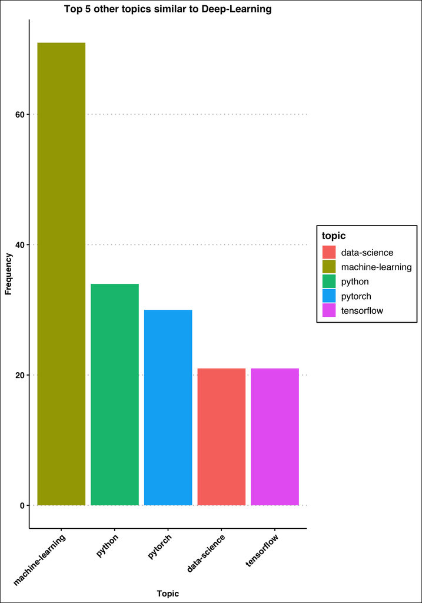

```r
item <- repository_info
topics <- lapply(item, function(repo) repo$topics)

topics <- unlist(topics)
other_topics <- topics[topics != 'deep-learning']

topic_freq <- table(other_topics)

#print(topics)
top_5_topics <- names(sort(topic_freq, decreasing = TRUE))[1:5]

top_5_topics_data <- data.frame(topic = top_5_topics, count = topic_freq[top_5_topics])

ggplot(top_5_topics_data, aes(x = reorder(topic, -count.Freq), y = count.Freq, fill = topic)) +
  geom_bar(stat = "identity") +
  labs(
    x = "Topic",
    y = "Frequency",
    title = "Top 5 other topics similar to Deep-Learning"
    ) +
  theme_clean() +
  theme(axis.text.x = element_text(angle = 45, hjust = 1),
        plot.title = element_text(color = "black", size = 12, hjust = 0.5),
        axis.text = element_text(face = "bold", size = 10),
        axis.title = element_text(face = "bold", size = 10)
        )
```

**Insights :**

The plot illustrates that “machine-learning” is the most prevalent topic that co-occurs with “Deep-Learning,” followed by “python,” which ranks second in frequency, and “pytorch,” which is third. Other topics like “data-science” and “tensorflow” have shown the same frequency as each other.

#### Second plot : A line chart showing the trend of the number of repos created each year.

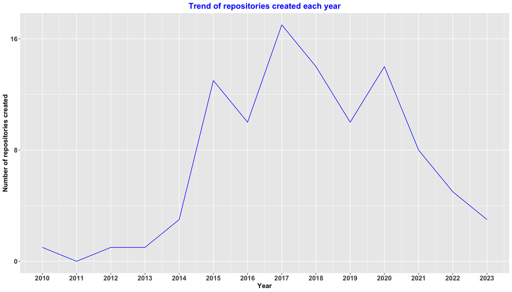

```r
# Extract the creation dates of the repositories
creation_dates <- repos_info |>
  select(created_at)

#year
creation_dates$year <- as.integer(substr(creation_dates$created_at, 1, 4))


repo_counts <- creation_dates |>
  group_by(year) |>
  summarise(num_repos = n())

all_years <- data.frame(year = min(repo_counts$year):max(repo_counts$year))
repo_counts <- all_years %>%
  left_join(repo_counts, by = "year") %>%
  mutate(num_repos = ifelse(is.na(num_repos), 0, num_repos))  # Replace NA counts with 0


ggplot(repo_counts, aes(x = year, y = num_repos)) +
  geom_line(color = "blue") +
  labs(
    x = "Year",
    y = "Number of repositories created",
    title = "Trend of repositories created each year"
  ) +
  scale_x_continuous(breaks = unique(repo_counts$year)) +
  scale_y_continuous(breaks = seq(0, max(repo_counts$num_repos), by = 8)) +
  theme(
    axis.text = element_text(face = "bold", size = 13),
    axis.title = element_text(face = "bold", size = 13),
    plot.title = element_text(color = "blue", face = "bold", size = 16, hjust = 0.5)
  )
```

**Insights :**

The above plot shows that highest number of repositories were created in 2017.